# EKV2019_demo

Johan Himberg

7/7/2019

# Vuoden 2019 eduskuntavaalien tuloksien estimointia postinumeroalueittain

## Taustaa

Entäpä jos haluaisi tutkia alueittain demografisten muuttujien ja äänestyskäyttäytymisen yhteyttä? Vaalien tulokset kuitenkin lasketaan äänestysalueittain. Postinumeroalueille on puolestaan runsaasti tilasto- ja karttatietoja Tilastokeskuksen avoimena Paavo-datana. En ole löytänyt yhtä laajaa äänestysalueittaista demografiatietoa ja karttatietoa koko maasta. Miten siis tehdä avoimella datalla analyysejä alueittain vaalien äänimäärien ja alueen demografian suhteen? Olen aiemmin törmäänyt kahteen käytännön ratkaisuun:

- lasketaan alueiden yhteisten pinta-alojen suhteita
- lasketaan alueiden yhteisten (asuin)rakennusten määrien suhteita

Jälkimmäinen on mahdollista toteuttaa Väestörekisterikeskuksen avoimella rakennustietodatalla, sillä rakennuksille on määrätty rakennustiedoissa äänestysalueen ja postinumero. Äänestäjien äänestysalue puolestaan määräytyy asuinkiinteistön äänestysalueen mukaan.

Heuristiikka ei ole tarkka monesta syystä:

- Rakennustyypit avoimessa datassa on luokiteltu karkeasti. Tiedetään vain, että kyseessä on asuin- tai toimistorakennus. Tosiasiassa rakennuksissa asuu eri määrä ihmisiä ja joissakin kunnissa aika isolle osalle rakennuksista puuttuu äänestysalue. Heuristiikassa oletetaan, että alueella oleva rakennusten asukkaiden jakauma on homogeeninen.
- Osa äänestysalueista ei kuulu mihinkään postinumeroalueeseen (ulkosuomalaiset, kotipaikattomat).
- Paavo-tilastointipostinumeroita on vähemmän kuin rakennustiedoissa olevia postinumeroita. Tässä ratkaisussa teen niin, että rakennukset joiden postinumero ei kuulu tilastointipostinumeroihin jätetään huomiotta
- Osa rakennuksen paikkatiedoista voi olla väärinkin, esimerkiksi koordinaatit, kuntatieto ja postinumero voivat olla ristiriidassa.
- Ylipäätään postinumeroalueita (~3000) on enemmän kuin äänestysalueita (~2000)

Menetelmä kelvannee suhteellisten äänimäärien tarkasteluun, mutta ei absoluuttisten äänimäärien tarkasteluun, esimerkiksi äänestysprosentin laskentaan, sillä postinumeroalueelle laskettu kokonaisäänimäärä voi ylittää Paavo-tiedon asukasluvun tai olla liian pieni. Äänien kokonaismäärän valtakunnallisesti pitäisi kuitenkin täsmätä poislukien äänestysalueet, joita ei vastaa mikään postinumero, siis esimerkiksi ulkosuomalaiset.

## Painokertoimien muodostaminen

### Haetaan data

Skripti ottaa käyttöön tarvittavia kirjastoja ja funktioita ja lataa tarvittaessa rakennus- ja vaalidatan (http://www.avoindata.fi, http://tulospalvelu.vaalit.fi) hakemistoon `data`. Jos tiedostot jo löytyvät, niitä ei haeta tai lasketa uudestaan. (Jos haluat että skripti hakee datat uudestaan, tyhjennä hakemisto `data`) Äänestystulokset tarvitaan äänestysalueittain (datassa ne ovat myös summattuna kunnittain jne). Seuraava vaihe kestää ensimmäisellä kerralla hetken.

```
## [1] "Data ladattu"
```

### Muodostetaan painokeroimet (siirtokertoimet)

Muodostetaan painot äänestysalueilta postinumeroalueille ja postinumeroalueilta äänestysalueille Tuloksena dataframe `aanestysalue2postinumero`.

Haetaan Paavo-datassa tilastointikäytössä olevat postinumerot, niiden pääasiallinen kunta ja alueen nimi. Tässä esimerkissä käyetään vuoden 2019 Paavo-datan postinumeroita. Datan käsittelystä enemmän (Alkuperäinen data Tilastokeskuksen Paavo-data, ref. 23.4. 2019, lisenssi: CC BY 4.0 https://creativecommons.org/licenses/by/4.0/deed.en

Äänestysalueen uniikki tunnus on äänestysalueen numero *ja* kuntanumero - tässä haetaan myös kunnan ja alueen nimi.

Esimerkki tiedoston alusta:

```
## # A tibble: 6 x 11
##   rakennustunnus kunta kadunnimi kuntanimi maakunta ETRS_TM35FIN_P
##   <chr>          <chr> <chr>     <chr>     <chr>             <int>
## 1 100004433E     005   Lehmustie Alajärvi  13              6989413
## 2 100004434F     005   Lehmustie Alajärvi  13              6989259
## 3 100004436J     005   Saarnitie Alajärvi  13              6989319
## 4 100004438L     005   Saarnitie Alajärvi  13              6989451
## 5 100004439M     005   Tammitie  Alajärvi  13              6989456
## 6 100004441P     005   Tammitie  Alajärvi  13              6989446
## # … with 5 more variables: ETRS_TM35FIN_I <int>, postinumero <chr>,
## #   aanestysalue_nro <chr>, aanestysalue_nimi <chr>,
## #   tilastointipostinumero <lgl>
```

Seuraava taulukko näyttää postinumeroalueet ja asunto/toimistorakennusten määrän rakennusdatan mukaan. Tilastointipostinumero TRUE/FALSE kertoo onko postinumero myös Paavo-datassa; näille numeroille löytyy myös alueen nimi. (Tilastoimattomilla postinumeroalueilla olevat rakennukset jätetään pois).

|  | postinumero | tilastointipostinumero | n | kuntanimi_postinumero | postinumero_nimi |
| --- | --- | --- | --- | --- | --- |
| 1 | 00000 | False | 7060 |  |  |
| 2 | 00002 | False | 2 |  |  |
| 3 | 00100 | True | 994 | Helsinki | Helsinki Keskusta - Etu-Töölö |
| 4 | 00120 | True | 352 | Helsinki | Punavuori |
| 5 | 00130 | True | 208 | Helsinki | Kaartinkaupunki |
| 6 | 00140 | True | 340 | Helsinki | Kaivopuisto - Ullanlinna |
| 7 | 00150 | True | 550 | Helsinki | Eira - Hernesaari |
| 8 | 00160 | True | 232 | Helsinki | Katajanokka |
| 9 | 00170 | True | 409 | Helsinki | Kruununhaka |
| 10 | 00180 | True | 572 | Helsinki | Kamppi - Ruoholahti |

[output cut: 3110 more lines]

Seuraavaksi lasketaan asuin/toimitilarakennusten määrä tilastointipostinumeroalueilla, äänestysalueilla ja näiden leikkauksissa. Liitetään alueiden nimitietoa ja keskimääräinen koordinaatti. Tätä käytetään poistamaan virheellisiä leikkauksia. Postinumero- ja äänestysalueiden leikkaukset, jotka siirtävät ja tuovat enintään 0.5% alueen äänistä poistetaan. Tämä on keino poistaa suuri osa virheellisistä leikkauksia, joita syntyy kun muutaman rakennuksen postinumero on väärä. Lisäksi on laskettu leikkauksen summittaisen etäisyys postinumeroalueen keskipistekoordinaatteihin. (Tähän on käytetty `geoshpere` kirjastoa, jolle datojen koordinaatit on muunnettu `proj4` kirjastolla pituus- ja leveysasteiksi, toivottavasti tähän tehtävään riittävällä tarkkuudella.)

Pelkästään etäisyyden perusteella leikkaamisen ongelma on se, että harvaan asutulla seudulla, esimerkiksi Lapissa, validit etäisydet ovat paljon suurempia kuin tiheästi asutuilla seuduilla. Tässä poistuu oikein olevia rakennuksiakin, mutta vaikutus ääniin on varmaankin vähäisempi kuin muut menetelmän epätarkkuudet.

Lasketaan kertoimet:

```r
aanestysalue2postinumero <- mutate(aanestysalue2postinumero,
    w_postinumero2aanestysalue = rakennukset_leikkaus / rakennukset_postinumero,
    w_aanestysalue2postinumero_ = rakennukset_leikkaus / rakennukset_aanestysalue,
    w_aanestysalue2postinumero = ifelse((w_aanestysalue2postinumero_ >= 0.5 / 100 | w_postinumero2aanestysalue > 0.5 / 100) &
                                   pono_leikkaus_km < 120, w_aanestysalue2postinumero_, NA)) %>%
  group_by(kunta, aanestysalue_nro) %>%
  mutate(w_aanestysalue2postinumero = w_aanestysalue2postinumero / sum(w_aanestysalue2postinumero, na.rm=TRUE)) %>%
  ungroup
```

Seuraavassa taulukossa kertoimia. Suluissa oleva painokerroin tarkoittaa, että ko. kerroin on nollattu lopputuloksessa. Etäisyys äänestysalue - leikkaus on keskipisteiden etäisyys kilometreinä. Esimerkiksi Evijärven äänestysalueella Evijärvi on rakennus jonka postinumero on Vantaan Varistolla (~355 km)

|  | äänestysalue | postinumeroalue | rakennusten määrä | kerroin äänestyslalueelta postinumerolle | etäisyys äänestysalue-leikkaus km |
| --- | --- | --- | --- | --- | --- |
| 1 | Alajärvi Itäinen | 62710 Kurejoki | 2 |  | 7.4 |
| 2 | Alajärvi Itäinen | 62720 Sissala | 1 | 0.00038 | 1 |
| 3 | Alajärvi Itäinen | 62740 Koskenvarsi | 1 | 0.00038 | 1.5 |
| 4 | Alajärvi Itäinen | 62750 Saukonkylä | 1 | 0.00038 | 3.2 |
| 5 | Alajärvi Itäinen | 62760 Menkijärvi | 2 | 0.00076 | 2.5 |
| 6 | Alajärvi Itäinen | 62800 Vimpeli Keskus | 1 |  | 15.7 |
| 7 | Alajärvi Itäinen | 62810 Savonjoki | 27 | 0.01033 | 4.3 |
| 8 | Alajärvi Itäinen | 62830 Luoma-Aho | 266 | 0.10172 | 0.5 |
| 9 | Alajärvi Itäinen | 62900 Alajärvi Keskus | 1488 | 0.56902 | 5.5 |
| 10 | Alajärvi Itäinen | 62920 Levijoki | 66 | 0.02524 | 2.8 |

[output cut: 10042 more lines]

### Esimerkki postinumeroalueen äänimäärien lähdealueista

Esimerkkinä postinumeroalue 00980: ensimmäisessä kuvassa painokertoimet joilla äänestysalueiden ääniä summataan alueelle ja toisessa kuvassa postinumeroalueita jotka saavat ääniä samoilta äänestysalueilta kuin 00980:

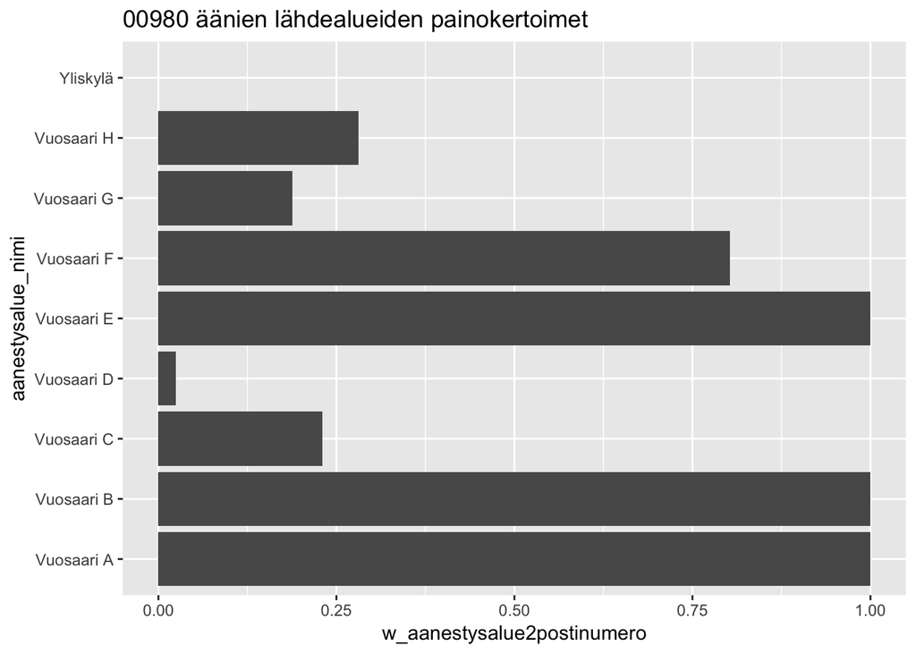

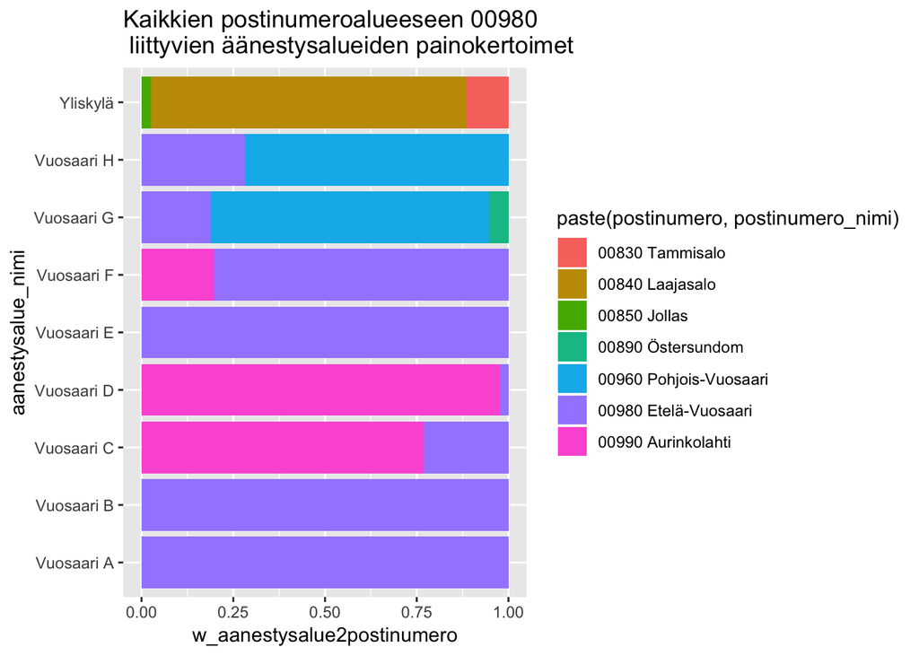

Esimerkiksi postinumeroalueelle 00980 Etelä-Vuosaari summataan lähes kaikki äänet äänestysalueilta Vuosaari A, B ja E, ja vaihteleva osa äänistä alueista C, D, F, F, G ja H. Yliskylän hyvin pieni osuus on nollattu.

## Paavo-data ja äänimäärien postinumeroalueittaiset osuudet

### Vaalidata

Aluksi haetaan ehdokkaiden perustiedot ja äänimäärät (ks. https://tulospalvelu.vaalit.fi/EKV-2019/fi/lasktila.html) ja yhdistetään valitsijayhdistyksiä ja pienimpiä yhteislistoja MUUT-ryhmäksi.

### Ehdokkaiden ja puolueiden arvioitu äänisaalis postinumeroalueilla

Seuraavaksi varsinainen painotus, jossa ehdokkaan äänimäärät äänestysalueilla kerrotaan painotuskertoimilla ja summataan postinumeroalueille. Talukossa osuuksia puolueittain ja postinumeroalueittain.

```r
aluekertoimet <- readRDS(file="data/w_aanestysalue2postinumero.rds")

aanet <-
  left_join(eduskuntavaalit,
            aluekertoimet,
            by=c("kunta", "aanestysalue_nro")) %>%
  mutate(aanet_yhteensa = aanet_yhteensa * w_aanestysalue2postinumero) %>%
  group_by(vaalipiiri, ehdokasnumero, postinumero) %>%
  summarise(ehdokkaan_aanet_postinumeroalueella = sum(aanet_yhteensa, na.rm=TRUE)) %>%
  ungroup %>%
  group_by(postinumero) %>%
  mutate(postinumeroalueen_kokonaisaanimaara = sum(ehdokkaan_aanet_postinumeroalueella, na.rm = TRUE)) %>%
  ungroup

saveRDS(aanet, file = "data/EKV2019_aanet_postinumeroittain.rds")
```

| kunta | postinumero | postinumero_nimi | (Ääniä) | EOP | FP | IP | KD | KESK | KOK | KP | KTP | LIB | MUUT | NYT | PIR | PS | RKP | SDP | SIN | SKE | SKP | STL | VAS | VIHR | vuosi |
| --- | --- | --- | --- | --- | --- | --- | --- | --- | --- | --- | --- | --- | --- | --- | --- | --- | --- | --- | --- | --- | --- | --- | --- | --- | --- |
| Helsinki | 00100 | Helsinki Keskusta - Etu-Töölö | 14793 | 0.00244 | 0.00892 | 0.00022 | 0.00966 | 0.02561 | 0.35016 | 0 | 0.00039 | 0.00343 | 7e-05 | 0.03316 | 0.01363 | 0.06308 | 0.08433 | 0.06663 | 0.00247 | 0.00038 | 0.00078 | 0.00191 | 0.07281 | 0.25991 | 2019 |
| Helsinki | 00120 | Punavuori | 5011.8 | 0.00322 | 0.00708 | 0.0006 | 0.00998 | 0.02046 | 0.31937 | 0 | 0.00026 | 0.00273 | 2e-05 | 0.0352 | 0.01751 | 0.06512 | 0.11216 | 0.0631 | 0.00214 | 0.00043 | 0.00051 | 0.00135 | 0.07902 | 0.25973 | 2019 |
| Helsinki | 00130 | Kaartinkaupunki | 1423 | 0.00218 | 0.00566 | 0 | 0.00842 | 0.01958 | 0.42697 | 0 | 0 | 0.00087 | 0 | 0.02702 | 0.01219 | 0.05819 | 0.1575 | 0.04687 | 0.00256 | 0.00092 | 0.00029 | 0.00087 | 0.04736 | 0.18254 | 2019 |
| Helsinki | 00140 | Kaivopuisto - Ullanlinna | 4421.6 | 0.00145 | 0.00556 | 0 | 0.00903 | 0.01869 | 0.3819 | 0 | 0.00042 | 0.00152 | 0 | 0.0285 | 0.01086 | 0.06018 | 0.1564 | 0.05341 | 0.00228 | 0.00046 | 0.00034 | 0.00225 | 0.05494 | 0.21182 | 2019 |
| Helsinki | 00150 | Eira - Hernesaari | 6591.6 | 0.00283 | 0.00701 | 0.00029 | 0.00844 | 0.01768 | 0.34845 | 0 | 0.00036 | 0.00278 | 0 | 0.03362 | 0.01645 | 0.0667 | 0.12362 | 0.06227 | 0.00292 | 0.00048 | 0.00044 | 0.00196 | 0.06818 | 0.2355 | 2019 |
| Helsinki | 00160 | Katajanokka | 3123 | 0.0016 | 0.00961 | 0.00064 | 0.01345 | 0.02273 | 0.32885 | 0 | 0 | 0.00288 | 0 | 0.02722 | 0.01537 | 0.07365 | 0.07045 | 0.10022 | 0.0016 | 0.00032 | 0 | 0.00128 | 0.09478 | 0.23535 | 2019 |
| Helsinki | 00170 | Kruununhaka | 4050.7 | 0.00216 | 0.01096 | 0.0001 | 0.01032 | 0.026 | 0.33299 | 0 | 0 | 0.0027 | 0 | 0.02859 | 0.01179 | 0.06152 | 0.08474 | 0.06575 | 0.00324 | 0.00034 | 0.00128 | 0.00167 | 0.08465 | 0.27119 | 2019 |
| Helsinki | 00180 | Kamppi - Ruoholahti | 9209.9 | 0.00134 | 0.01008 | 0.00026 | 0.01236 | 0.02141 | 0.28015 | 0 | 0.00052 | 0.00467 | 0.0001 | 0.03887 | 0.01721 | 0.0893 | 0.0587 | 0.09755 | 0.00361 | 0.00056 | 0.00108 | 0.00318 | 0.08716 | 0.27189 | 2019 |
| Helsinki | 00190 | Suomenlinna | 417.5 | 0.0001 | 0.01377 | 0 | 0.02059 | 0.01649 | 0.18009 | 0 | 2e-05 | 6e-05 | 0 | 0.01914 | 0.00714 | 0.05628 | 0.02226 | 0.1262 | 0.00231 | 4e-05 | 0 | 0.00909 | 0.22802 | 0.29838 | 2019 |
| Helsinki | 00200 | Lauttasaari | 10605.6 | 0.00136 | 0.00744 | 0.00027 | 0.01388 | 0.02172 | 0.32452 | 0 | 0.00019 | 0.00279 | 9e-05 | 0.03516 | 0.01325 | 0.07156 | 0.11323 | 0.07322 | 0.0044 | 0 | 0.00034 | 0.0009 | 0.05666 | 0.25902 | 2019 |

[output cut: 3012 more lines]

### Paavo-data

Tilastokeskuksen Paavo-data (https://www.stat.fi/tup/paavo/index_en.html) on haettu valmiiksi vuosilta 2018-2019 (ks. https://github.com/jhimberg/paavodata). Datassa on myös laskettuna aggregaatteja kolmen ja kahden ensimmäinsen numeron määrittämille suuremmille alueille `pono_level`, mutta tässä otetaan postinumeroalueet (kaikki viisi numeroa) Paavo-datasta (versio 2019) ja yhdistetään se puolueiden äänimääriin.

Taulukossa Paavo-datan muuttujien koodeja vastaavat nimet löytyvät `paavo$vars` Ks. tarkemmin https://github.com/jhimberg/paavodata.

```
## [1] "Paavo-data ok"
```

#### Paavo datan muuttujat

```r
DT::datatable(paavo$vars, rownames=FALSE)
```

| nimi | name | koodi | paavo.vuosi.offset | aggr | weight | ratio.base |
| --- | --- | --- | --- | --- | --- | --- |
| Postinumerolalueen nimi | Postal area name | nimi |  |  |  |  |
| Postinumeroalue | Zip code | pono |  |  |  |  |
| Paavo-datan vuosi | Year of Paavo data | vuosi |  |  |  |  |
| Postinumeroalueen pinta-ala | Area | pinta_ala |  | sum |  |  |
| X-koordinaatti | X coordinate | euref_x |  | min |  |  |
| Y-koordinaatti | Y coordiante | euref_y |  | min |  |  |
| Kuntanumero | Commune number | kuntano |  | min |  |  |
| Asukkaat yhteensä HE | Inhabitants HE | he_vakiy | -2 | sum |  |  |
| Naiset HE | Females HE | he_naiset | -2 | sum |  | he_vakiy |
| Miehet HE | Males HE | he_miehet | -2 | sum |  | he_vakiy |

[output cut: 184 more lines]

`_osuus` päätteiset muuttujat eivät ole alkuperäisiä: niihin on yritetty valmiiksi laskea osuuksia väestöstä , esim. `ko_yl_kork_osuus` on laskettu ko_yl_kork_osuus / ko_ika_18y. Jakava löytyy sarakkeesta `ratio.base`. Kun Paavo-datan vuosiversioluvusta vähentää `paavo.vuosi.offset` pitäisi saada vuosi jonka lopusta data vasrsinaisesti on.

### Esimerkkejä yhdistetyllä datalla:

#### Helsingin postinumeroalueet

Puolueen ääniosuuden ja yksinasuvien nuorten osuuden suhde alueella. Esimerkissä VIHR / KAIKKI on vihreiden ääniosuus kaikista alueen äänistä. (Osuudet ovat välillä 0…1, eli 1 vastaa 100%).

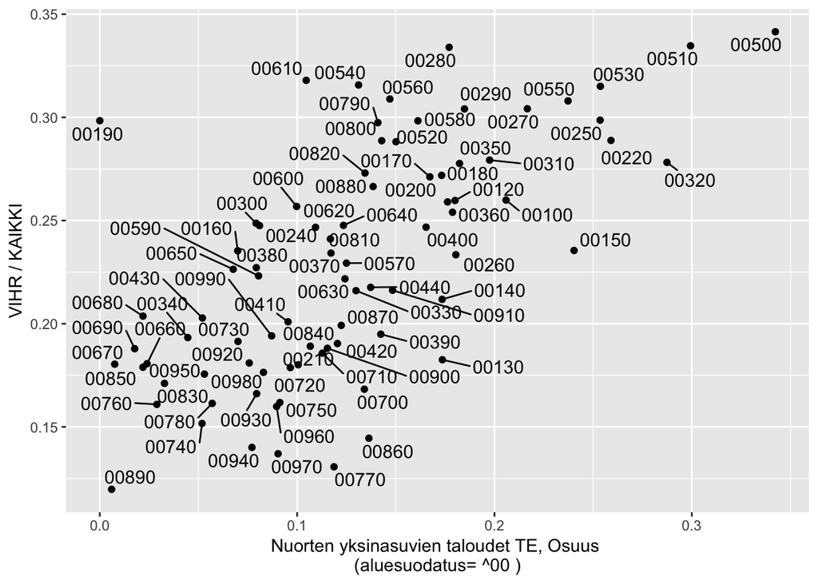

```r
postinumero_pattern <- "^00"  # 00 ~ Helsinki
selittaja <- "te_nuor_osuus"
selitettava <- "VIHR / KAIKKI"
alueen_minimiaanimaara <- 100

ggplot(
  filter(aanet_ja_paavodata, grepl(postinumero_pattern, postinumero) & KAIKKI >= alueen_minimiaanimaara),
  aes_string(y = selitettava, x = selittaja,
      label = "postinumero",
      weight = "KAIKKI"
      )) +
  # geom_text(size=4) +  vaihtoehto ilman ggrepel-kirjastoa
  geom_point() + ggrepel::geom_text_repel(size=4) + # vaihtoehto jossa labelit ei mene päällekäin...
  ylab(selitettava) +
  xlab(paste(filter(paavo$vars, koodi == selittaja) %>% pull(nimi), "\n(aluesuodatus=", postinumero_pattern, ")"))
```

### Karttakuvia

Paavo-datan yhteydessä on myös postinumeroalueiden karttapohja. Sen resoluutiota on pienennetty. Pienimpiä saaria on poistettu ja polygonien pisteiden määrää on vähennetty.

```r
source("map_and_names/paavo_functions.R")
```

```
## here() starts at /Users/jhimberg/Projects/aanestysalue2postinumero
```

```r
df <- transmute(aanet_ja_paavodata,
                pono = postinumero,
                KOK_osuus = KOK/KAIKKI,
                tooltip = paste0(postinumero, " ",
                                toupper = kuntano2nimi(kuntano),
                                "\n", nimi, "\n",
                                as.numeric(round(KOK_osuus * 100)), "%")) %>%
  filter(grepl("^00", pono))


map_fi_zipcode_interactive(df,
                           title_label = "KOK osuus alueella ^00",
                           map = "2019",
                           colorscale = scale_fill_distiller,
                           type = "seq",
                           palette="YlOrRd",
                           direction = 1) %>%
  girafe(ggobj = .) %>%
  girafe_options(x=., opts_zoom(min = .5, max = 5))
```

[interactive chart not shown]

```r
source("map_and_names/paavo_functions.R")

df <- transmute(aanet_ja_paavodata,
                pono = postinumero,
                hr_hy_tul_osuus,
                tooltip = paste0(postinumero, " ",
                                toupper=kuntano2nimi(kuntano),
                                "\n", nimi, "\n",
                                as.numeric(round(hr_hy_tul_osuus * 100)), "%")) %>%
  filter(grepl("^00", pono))


map_fi_zipcode_interactive(df,
                           title_label = "Ylimpään tuloluokaan kuuluvien asukkaiden osuus",
                           map = "2019",
                           colorscale = scale_fill_distiller,
                           type = "seq",
                           palette="YlOrRd",
                           direction = 1) %>%
  girafe(ggobj = .) %>%
  girafe_options(x=., opts_zoom(min = .5, max = 5))
```

[interactive chart not shown]